# General Linear Models: Statistical Inference

## Introduction

- In our previous lectures, we discussed correlation and estimation of regression coefficients.
  - Correlation is unitless.
  - Regression coefficients retain the units of $x$ and $y$ for interpretations.
- In this lecture, we introduce statistical inference for regression:
  - Confidence intervals for $\beta_i$
  - Overall test for a significant regression line
  - Test for individual predictors

## `R` Set Up

```r
library(tidyverse)
library(ssstats)
library(broom)
training <- read_csv("https://raw.githubusercontent.com/samanthaseals/SDSI/refs/heads/main/files/data/lectures/7-1-training.csv")
wellness <- read_csv("https://raw.githubusercontent.com/samanthaseals/SDSI/refs/heads/main/files/data/lectures/7-2-wellness.csv")
reports <- read_csv("https://raw.githubusercontent.com/samanthaseals/SDSI/refs/heads/main/files/data/lectures/7-3-reports.csv")
break_room <- read_csv("https://raw.githubusercontent.com/samanthaseals/SDSI/refs/heads/main/files/data/lectures/7-4-break_room.csv")
bakery_sales <- read_csv("https://raw.githubusercontent.com/samanthaseals/SDSI/refs/heads/main/files/data/lectures/7-5-bakery_sales.csv")
cafe_sales <- read_csv("https://raw.githubusercontent.com/samanthaseals/SDSI/refs/heads/main/files/data/lectures/7-6-cafe_sales.csv")
```

## Regression Assumptions

- Recall the general linear model,

$$y = \beta_0 + \beta_1 x_1 + \beta_2 x_2 + ... + \beta_k x_k + \varepsilon$$

- Like in ANOVA, we assume

$$\varepsilon \sim N(0, \sigma^2)$$

## Regression Assumptions (`R`)

- We will use the `reg_check()` function from `library(ssstats)`.
- Generic syntax:

```r
model_name |> reg_check()
```

## Example 1

- Recall the `training` dataset,
  - Is there a relationship between weekly practice hours ($x$) and exam score ($y$)?

| practice_hours | exam_score |
| --- | --- |
| 6.7 | 68.7 |
| 1.4 | 56.6 |
| 1.4 | 63.0 |

## Example 1

- Is there a relationship between weekly practice hours ($x$) and exam score ($y$)?

```r
m1 <- glm(exam_score ~ practice_hours,
          data = training)
m1 |> coefficients()
```

```
   (Intercept) practice_hours
     57.253240       3.108387
```

## Example 1

- Checking assumptions,

```r
m1 |> reg_check()
```

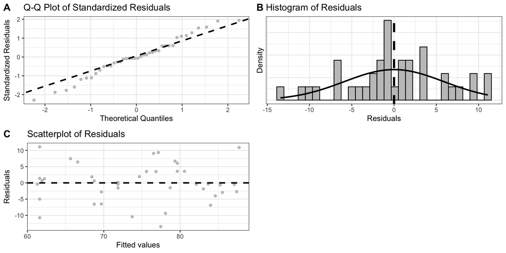

## Example 2

- Recall the `reports` dataset,
  - Is there a relationship between officer height ($x$) and report accuracy ($y$)?

| height_cm | report_accuracy |
| --- | --- |
| 198 | 75.5 |
| 129 | 82.7 |
| 89 | 78.0 |

## Example 2

- Is there a relationship between officer height ($x$) and report accuracy ($y$)?
- Constructing the model,

```r
m2 <- glm(report_accuracy ~ height_cm,
          data = reports)
m2 |> coefficients()
```

```
 (Intercept)    height_cm
80.430106777  0.009226122
```

## Example 2

- Checking assumptions,

```r
m2 |> reg_check()
```

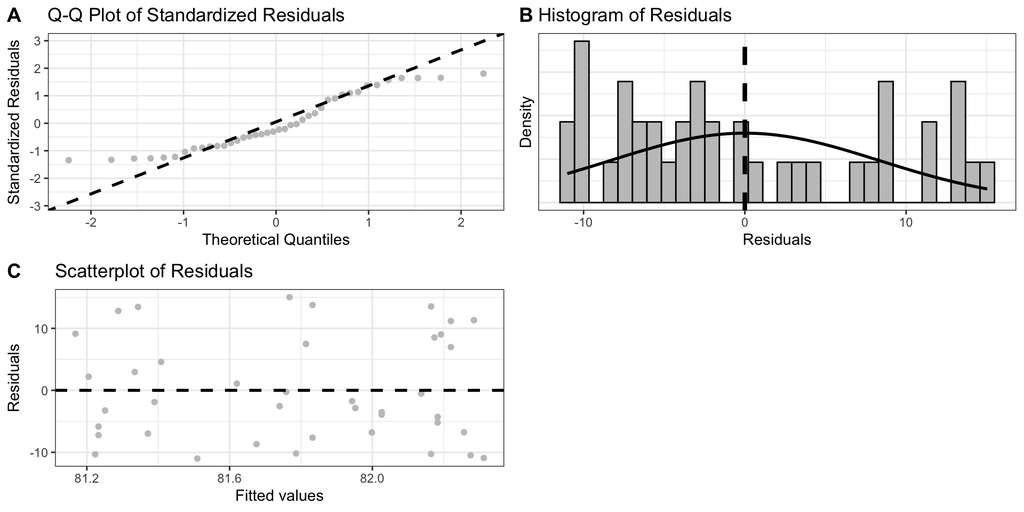

## Statistical Inference in Linear Regression

- Once we confirm that our residuals follow a normal distribution, we begin to make inference.
  - Omnibus test for the model.
  - Individual predictor tests.
    - Confidence intervals for $\beta_i$.
- If the residuals do *not* follow a normal distribution with mean 0 and some common variance, $\sigma^2$, we do *not* follow our modeling up with formal hypothesis tests.

## Confidence Intervals for $\beta_i$

- Like all statistics, we can put a confidence interval on $\beta_i$.
  - When reporting regression results, I *always* include the corresponding CI.

$$\hat{\beta}_i \pm t_{\alpha/2, n-k-1} \text{ SE}_{\hat{\beta}_i}$$

## Confidence Intervals for $\beta_i$ (`R`)

- We can use the `tidy()` function to get regression results with confidence intervals,

```r
model_name |> tidy(conf.int = TRUE)
```

## Example 1

- Returning to our first example,
  - Is there a relationship between weekly practice hours ($x$) and exam score ($y$)?

```r
m1 |> tidy(conf.int = TRUE)
```

| term | estimate | conf.low | conf.high |
| --- | --- | --- | --- |
| (Intercept) | 57.253240 | 52.988825 | 61.51765 |
| practice_hours | 3.108388 | 2.418945 | 3.79783 |

## Example 3

- Recall the `bakery_sales` dataset,
  - How are advertising spending ($x_1$), foot traffic ($x_2$), temperature ($x_3$), and discounts ($x_4$) related to daily bakery sales ($y$)?

| advertising_dollars | foot_traffic | temperature_c | discount_percent | sales_dollars |
| --- | --- | --- | --- | --- |
| 12.72 | 136 | 21.7 | 6.5 | 553.84 |
| 70.45 | 145 | 28.1 | 13.9 | 838.67 |
| 82.13 | 144 | 18.8 | 13.7 | 842.29 |

## Example 3

- Recall the `bakery_sales` dataset,
  - How are advertising spending ($x_1$), foot traffic ($x_2$), temperature ($x_3$), and discounts ($x_4$) related to daily bakery sales ($y$)?

```r
m3 |> tidy(conf.int = TRUE)
```

| term | estimate | conf.low | conf.high |
| --- | --- | --- | --- |
| (Intercept) | 142.694320 | 27.014973 | 258.373666 |
| advertising_dollars | 1.734312 | 1.159990 | 2.308634 |
| foot_traffic | 1.383370 | 1.206676 | 1.560065 |
| temperature_c | 8.607033 | 4.743606 | 12.470459 |
| discount_percent | 11.922056 | 8.979698 | 14.864413 |

## Hypothesis Testing: Significant Regression Line

- We can use the likelihood ratio test to test for a “significant regression” line.
  - A significant regression line means that there is a non-zero slope among all slopes.
- **Hypotheses**
  - $H_0: \ \beta_1 = ... = \beta_k = 0$
  - $H_1:$ at least one is different
- **Test Statistic and *p*-Value**
  - $\chi^2_0$ (from R)
  - $p = \text{P}[\chi^2_{k} \ge \chi^2_0]$

## Hypothesis Testing: Significant Regression Line (R)

- We will use the `anova()` function to test for a significant model.

```r
full <- glm(y ~ x_1 + x_2 + ... + x_k, data = dataset_name)
reduced <- glm(y ~ 1, data = dataset_name)
anova(reduced, full, test = "Chisq")
```

## Example 1

- Revisiting our model from Example 1,

$$\hat{\text{exam}} = 57.25 + 3.11 \text{ practice}$$

```r
full <- glm(exam_score ~ practice_hours, data = training)
reduced <- glm(exam_score ~ 1, data = training)
anova(reduced, full, test = "Chisq")
```

| Resid. Df | Resid. Dev | Df | Deviance | Pr(>Chi) |
| --- | --- | --- | --- | --- |
| 39 | 4123.858 | NA | NA | NA |
| 38 | 1349.925 | 1 | 2773.933 | 0 |

## Example 1

- **Hypotheses:**
  - $H_0: \beta_1 = 0$
  - $H_1: \beta_1 \ne 0$
- **Test Statistic and $p$-Value:**
  - $\chi^2_0 = 2773.9$
  - $p < 0.001$
- **Rejection Region:**
  - Reject $H_0$ if $p < \alpha$; $\alpha = 0.05$
- **Conclusion and Interpretation:**
  - Reject $H_0$. There is sufficient evidence to suggest that the slope is non-zero.

## Example 3

- Revisiting our model from Example 3,

```r
full <- glm(sales_dollars ~ advertising_dollars + foot_traffic + temperature_c + discount_percent, data = bakery_sales)
reduced <- glm(sales_dollars ~ 1, data = bakery_sales)
anova(reduced, full, test = "Chisq")
```

| Resid. Df | Resid. Dev | Df | Deviance | Pr(>Chi) |
| --- | --- | --- | --- | --- |
| 39 | 796611.34 | NA | NA | NA |
| 35 | 84293.17 | 4 | 712318.2 | 0 |

## Example 3

- **Hypotheses:**
  - $H_0: \beta_1 = \beta_2 = \beta_3 = \beta_4 = 0$
  - $H_1:$ at least one $\beta_i \ne 0$
- **Test Statistic and $p$-Value:**
  - $\chi^2_0 = 712318$
  - $p < 0.001$
- **Rejection Region:**
  - Reject $H_0$ if $p < \alpha$; $\alpha = 0.05$
- **Conclusion and Interpretation:**
  - Reject $H_0$. There is sufficient evidence to suggest that at least one of the slopes is non-zero.

## Hypothesis Testing: Individual Predictors

- We can use the $t$-test to test for “significant predictors”
  - A significant predictor means that there is a non-zero slope between the outcome and this specific $x_i$.
- **Hypotheses**
  - $H_0: \ \beta_i = 0$
  - $H_1: \ \beta_i \ne 0$
- **Test Statistic**

$$t_0 = \frac{\hat{\beta}_i}{\text{SE}_{\beta_i}} \sim t_1$$

## Hypothesis Testing: Individual Predictors (`R`)

- We again turn to `tidy()` for output,

```r
model_name |> tidy(conf.int = TRUE)
```

## Example 1

- Returning to our first example,

```r
m1 |> tidy(conf.int = TRUE)
```

| term | estimate | std.error | statistic | p.value | conf.low | conf.high |
| --- | --- | --- | --- | --- | --- | --- |
| (Intercept) | 57.253240 | 2.175762 | 26.314113 | 0 | 52.988825 | 61.51765 |
| practice_hours | 3.108388 | 0.351763 | 8.836595 | 0 | 2.418945 | 3.79783 |

- Practice time is a significant predictor of exam score ($p < 0.001$).

## Example 3

- Returning to our third example,

```r
m3 |> tidy(conf.int = TRUE)
```

| term | estimate | std.error | statistic | p.value | conf.low | conf.high |
| --- | --- | --- | --- | --- | --- | --- |
| (Intercept) | 142.694320 | 59.0211593 | 2.417681 | 0.0209643 | 27.014973 | 258.373666 |
| advertising_dollars | 1.734312 | 0.2930268 | 5.918610 | 0.0000010 | 1.159990 | 2.308634 |
| foot_traffic | 1.383370 | 0.0901519 | 15.344879 | 0.0000000 | 1.206676 | 1.560065 |
| temperature_c | 8.607033 | 1.9711721 | 4.366454 | 0.0001068 | 4.743606 | 12.470459 |
| discount_percent | 11.922056 | 1.5012304 | 7.941523 | 0.0000000 | 8.979698 | 14.864413 |

- All predictors are significant (all $p < 0.001$).

## Example 4

- A cafe owner in Savanna Central brings you a spreadsheet: “We’ve been tracking everything! Can you help us figure out which of these are related to sales?”
- We have collected data from 40 days to answer the following question:
  - Which of the five explanatory variables are associated with daily cafe sales after accounting for the other variables?

| advertising_dollars | foot_traffic | temperature_c | music_volume_db | window_display_hours | sales_dollars |
| --- | --- | --- | --- | --- | --- |
| 16.46 | 239 | 25.3 | 66.7 | 3.5 | 639.90 |
| 16.97 | 398 | 17.5 | 52.7 | 2.0 | 1018.52 |
| 28.16 | 123 | 18.6 | 53.9 | 10.1 | 438.26 |

## Example 4

- Constructing the model,
  - Which of the five explanatory variables are associated with daily cafe sales after accounting for the other variables?

```r
m4 <- glm(sales_dollars ~ window_display_hours + music_volume_db + temperature_c + foot_traffic + advertising_dollars,
          data = cafe_sales)
m4 |> tidy(conf.int = TRUE)
```

| term | estimate | std.error | statistic | p.value | conf.low | conf.high |
| --- | --- | --- | --- | --- | --- | --- |
| (Intercept) | 214.8508016 | 92.5198490 | 2.3222131 | 0.0263440 | 33.515230 | 396.186373 |
| window_display_hours | 0.6401574 | 2.9259721 | 0.2187845 | 0.8281259 | -5.094642 | 6.374957 |
| music_volume_db | 0.1185153 | 1.2434609 | 0.0953108 | 0.9246275 | -2.318623 | 2.555654 |
| temperature_c | -3.9037541 | 2.5040629 | -1.5589681 | 0.1282647 | -8.811627 | 1.004119 |
| foot_traffic | 1.8625319 | 0.1215631 | 15.3215187 | 0.0000000 | 1.624273 | 2.100791 |
| advertising_dollars | 2.9437998 | 0.3958345 | 7.4369464 | 0.0000000 | 2.167978 | 3.719621 |

## Example 4

- Is this a significant regression model?

```r
full <- glm(sales_dollars ~ window_display_hours + music_volume_db + temperature_c + foot_traffic + advertising_dollars, data = cafe_sales)
reduced <- glm(sales_dollars ~ 1, data = cafe_sales)
anova(reduced, full, test = "Chisq")
```

| Resid. Df | Resid. Dev | Df | Deviance | Pr(>Chi) |
| --- | --- | --- | --- | --- |
| 39 | 1378745.9 | NA | NA | NA |
| 34 | 133178.7 | 5 | 1245567 | 0 |

## Example 4

- **Hypotheses:**
  - $H_0: \beta_1 = \beta_2 = \beta_3 = \beta_4 = \beta_5 =0$
  - $H_1:$ at least one $\beta_i \ne 0$
- **Test Statistic and $p$-Value:**
  - $\chi^2_0 = 1245567$
  - $p < 0.001$
- **Rejection Region:**
  - Reject $H_0$ if $p < \alpha$; $\alpha = 0.05$
- **Conclusion and Interpretation:**
  - Reject $H_0$. There is sufficient evidence to suggest that at least one of the slopes is non-zero.

## Example 4

- Looking at individual predictors,

```r
m4 <- glm(sales_dollars ~ window_display_hours + music_volume_db + temperature_c + foot_traffic + advertising_dollars,
          data = cafe_sales)
m4 |> tidy(conf.int = TRUE)
```

| term | estimate | std.error | statistic | p.value | conf.low | conf.high |
| --- | --- | --- | --- | --- | --- | --- |
| (Intercept) | 214.8508016 | 92.5198490 | 2.3222131 | 0.0263440 | 33.515230 | 396.186373 |
| window_display_hours | 0.6401574 | 2.9259721 | 0.2187845 | 0.8281259 | -5.094642 | 6.374957 |
| music_volume_db | 0.1185153 | 1.2434609 | 0.0953108 | 0.9246275 | -2.318623 | 2.555654 |
| temperature_c | -3.9037541 | 2.5040629 | -1.5589681 | 0.1282647 | -8.811627 | 1.004119 |
| foot_traffic | 1.8625319 | 0.1215631 | 15.3215187 | 0.0000000 | 1.624273 | 2.100791 |
| advertising_dollars | 2.9437998 | 0.3958345 | 7.4369464 | 0.0000000 | 2.167978 | 3.719621 |

## Example 4

- Looking at the individual predictors,
  - Window display is not a significant predictor ($p = 0.828$)
  - Music volume is not a significant predictor ($p = 0.925$)
  - Temperature is not a significant predictor ($p = 0.128$)
  - Foot traffic is a significant predictor ($p < 0.001$)
  - Advertising dollars is a significant predictor ($p < 0.001$)

## Wrap Up

- We have covered the basics of linear regression.
- In Statistics for Data Science II, you will learn more about statistical modeling.
  - A deeper dive into ordinary least squares.
    - Additional predictor types.
    - Model fit and diagnostics.
    - Data visualization.
  - Logistic regression.
  - Poisson and negative binomial regressions.